Thanh M. Brown Data Analyst · Machine Learning & Analytics

← Back to projects

**02** — Clinical ML · Epidemiology · Matched Case-Control

# Osteoporosis Risk Classification & Recall Asymmetry

Why do models miss osteoporosis cases on a perfectly balanced dataset? Across 61,026 matched patients, classifiers reach ROC-AUCs up to 0.79 yet miss 40–49% of cases. I validated the cohort by reproducing its source study's published odds ratio, then investigated where the gap comes from.

- Matched case-control
- Conditional logistic regression
- Multiple imputation
- Model diagnostics
- Threshold & recall analysis
- Subgroup analysis

[GitHub repository](https://github.com/ThanhNguyen93/osteoporosis_risk_classifier)

**61,026**

matched patients, 1:1 by design

**0.79**

top ROC-AUC (XGBoost)

**40–49%**

of cases missed at the 0.5 cutoff

**3.98**

reproduced odds ratio vs. 3.97 published

## The puzzle

The data are the matched case-control cohort from Usala et al. (2015), rebuilt from the underlying EHR records. The cohort is exactly 50/50 cases and controls by construction. Even so, every model recalls controls far better than cases at the default 0.5 cutoff.

Control recallCase recall

Logistic regressionAUC 0.749

0.83

0.54

Linear SVMAUC 0.738

0.84

0.51

Random forestAUC 0.789

0.82

0.60

XGBoostAUC 0.790

0.83

0.59

Neural networkAUC 0.777

0.82

0.59

Out-of-fold predictions, 10-fold cross-validation split by matched pair, full-record lab columns excluded.

For screening, a strong ranking score does not mean a model catches most patients with the disease. Where the threshold sits, and who falls just below it, decides that.

## The evidence

All five models separate cases from controls well above chance.

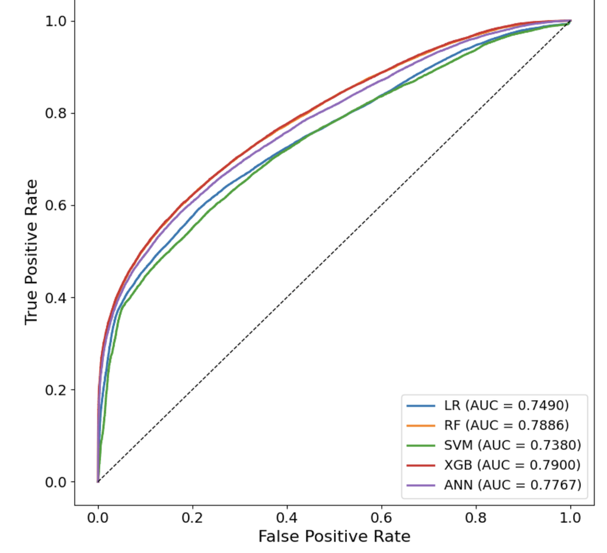

ROC curves, out-of-fold, full-record lab columns excluded.

But cases are bimodal, and one of their peaks overlaps the controls just under the 0.5 cutoff.

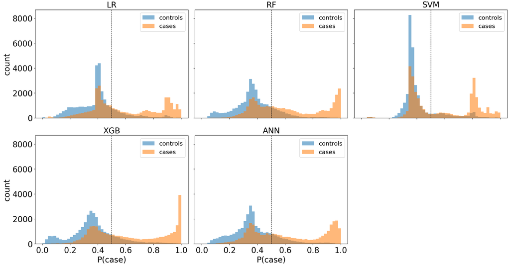

Predicted probability by true class; the dashed line is the 0.5 cutoff. Controls are largely unimodal, clustered around 0.35–0.40. Cases are bimodal: one peak overlaps the controls, the other sits high. Tree ensembles (Random Forest and XGBoost) push that high-signal group all the way to 1.0, while logistic regression and linear SVM place it lower, around 0.9 and 0.8. The neural network lands in between, with its high group peaking near 0.95.

The same distributions, viewed through their medians: controls sit tightly below the cutoff, while the typical case sits barely above it.

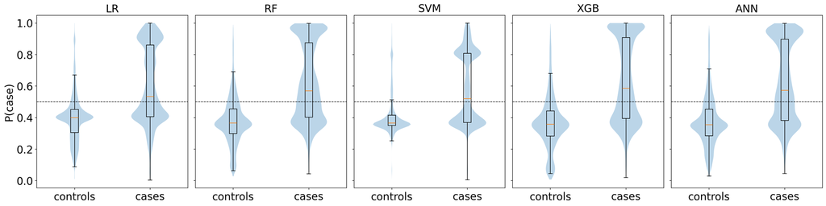

Same out-of-fold predictions as the histograms above, shown as violin plots with box plots. Control medians fall around 0.36–0.40; case medians fall around 0.52–0.59, with case scores spread across the full range. Pooled across both classes, the median prediction is only 0.39–0.43, so the models label just 34–39% of patients positive on a 50/50 cohort.

## Validation

Before any modeling, I rebuilt the source study (Usala et al., 2015) and reproduced its hyponatremia–osteoporosis association with conditional logistic regression stratified on the matched pairs, pooling five BMI imputations by Rubin's rules.

**3.98**reproduced (95% CI 3.60–4.40)

**3.97**published

**Imputation check**

BMI was missing for about 68% of patients, far more often among cases, yet adjusting for it barely moved the association, so the reproduction is not driven by the imputation.

## Safeguards

Matched observational EHR data breaks assumptions that standard ML pipelines take for granted.

**Temporal leakage**

Full-record lab summaries include post-diagnosis measurements (sodium is recorded for 99.6% of patients across the full record vs. 67.4% before the index date), so all full-record features were excluded.

**Pair-grouped cross-validation**

Folds are assigned by matched stratum, so a case and its matched control never fall on opposite sides of a split.

**Within-pair discrimination**

Global AUC pools all cases against all controls, so it can reflect differences between matched pairs rather than between a case and its own control. Within-pair accuracy (pair_acc, equivalent to within-stratum AUC in 1:1 matching) is reported alongside it, since it tests the comparison the design supports.

## Finding

**Not class imbalance**

Exact 50/50 balance rules it out by design.

**Not a single algorithm**

The gap persists from linear models to gradient boosting. Moving from logistic regression to XGBoost lifts AUC from 0.749 to 0.790 but only narrows the gap from 0.29 to 0.24. A neural network (AUC 0.777) sits in the same band with the same gap.

**Ranking is not the problem**

Tree ensembles rank a case above its matched control about 79% of the time, well above chance.

**Case heterogeneity**

The evidence so far points to a high-signal case subgroup the models catch, alongside a second group that overlaps heavily with controls.

Stage 3 is in progress: separating missingness flags from lab deciles and computing SHAP values for the two confidence groups.

## Tech Stack

- **Language**Python
- **Modeling**scikit-learn · XGBoost
- **Statistics**statsmodels
- **Methods**Conditional logit · Rubin's rules

Code, notebooks, and full documentation are in the repository. Patient data is institutional and not redistributed.

[Read the full analysis on GitHub](https://github.com/ThanhNguyen93/osteoporosis_risk_classifier)